# Microbial Compositional Analysis

Shawn Xinyu Wang

April 29, 2025

## Goals

In this file, we will perform compositional analysis of our scaled (normalized) gut microbiome dataset from the RBX2660 clinical trial. Load in the scaled/normalized phyloseq object containing ASV abundance, taxonomy, metadata, and tree. Calculate the relative abundances of microbial taxa at multiple taxonomic levels: A. Phylum B. Genus C. ASV Visualize taxonomic composition across patient groups (Donor, RI0, RI7, SI0, SI7) and over time.

We will use the scaled_physeq.RData object, generated in analysis/06_Ordination/, which contains sequencing depth-normalized data based on midpoint_rooted_physeq.RData created in analysis/04_PhylogeneticTree/.

## Outputs

Compositional Data Considerations Microbial abundance data from 16S rRNA gene sequencing are compositional in nature — that is, they represent relative proportions rather than absolute counts. This constraint introduces potential artifacts (e.g., false correlations) when using standard statistical methods designed for absolute data. It is important to keep these limitations in mind when interpreting changes in taxonomic abundances across groups.

Because microbiome data are compositional, changes in the relative abundance of one taxon necessarily affect the measured abundance of others, even if their absolute abundances remain unchanged. Thus, interpretation should focus on relative shifts between groups rather than assuming absolute increases or decreases in specific taxa.

# Setup

## Load Packages

```r
# Load in the packages
pacman::p_load(tidyverse, devtools, DT, phyloseq, patchwork,
               install = FALSE)
```

## 1. Load in Scaled Phyloseq object

```r
# Load the scaled (normalized) phyloseq object
load("data/06_Ordination/scaled_physeq.RData")

# Quick look at the loaded phyloseq object
scaled_physeq
```

```
## phyloseq-class experiment-level object
## otu_table()   OTU Table:         [ 1160 taxa and 173 samples ]
## sample_data() Sample Data:       [ 173 samples by 52 sample variables ]
## tax_table()   Taxonomy Table:    [ 1160 taxa by 7 taxonomic ranks ]
## phy_tree()    Phylogenetic Tree: [ 1160 tips and 1159 internal nodes ]
```

```r
# Intuition check — check sequencing depth range after scaling
min(sample_sums(scaled_physeq))
```

```
## [1] 3823
```

```r
range(sample_sums(scaled_physeq))
```

```
## [1] 3823 3835
```

# Taxonomic Analysis!

## A. Phylum

```r
# Create a phylum-level dataframe
phylum_df <-
  scaled_physeq %>%
  # Agglomerate ASVs at the Phylum level
  tax_glom(taxrank = "Phylum") %>%
  # Transform to relative abundances
  transform_sample_counts(function(x) x / sum(x)) %>%
  # Melt into long dataframe
  psmelt()

# Inspect phylum-level abundances
phylum_df %>%
  group_by(Phylum) %>%
  summarize(mean_PercAbund = round(mean(Abundance), digits = 4)) %>%
  arrange(desc(mean_PercAbund)) %>%
  datatable()
```

|  | Phylum | mean_PercAbund |
| --- | --- | --- |
| 1 | Firmicutes | 0.7115 |
| 2 | Proteobacteria | 0.1222 |
| 3 | Verrucomicrobiota | 0.0939 |
| 4 | Bacteroidota | 0.0466 |
| 5 | Actinobacteriota | 0.0223 |
| 6 | Desulfobacterota | 0.0033 |
| 7 | Campylobacterota | 0 |
| 8 | Cyanobacteria | 0 |
| 9 | Fusobacteriota | 0 |
| 10 | Synergistota | 0 |

```r
# Identify Top 6 most abundant Phyla
top6_phyla <-
  phylum_df %>%
  group_by(Phylum) %>%
  summarize(mean_PercAbund = mean(Abundance)) %>%
  arrange(desc(mean_PercAbund)) %>%
  slice_head(n = 6) %>%
  pull(Phylum)
```

INTERPRETATION #2: At this stage, we calculated the overall mean relative abundances across all samples, without yet distinguishing between Donor and patient groups (SI/RI before and after treatment). Across the entire dataset, the most abundant phylum was Firmicutes (71.15%), followed by Proteobacteria (12.22%) and Verrucomicrobiota (9.39%). Bacteroidota (4.66%) and Actinobacteriota (2.23%) were less dominant. This initial overview provides a sense of which phyla are most prevalent in the dataset, but further group-specific analyses are necessary to assess how RBX2660 treatment influences gut microbial composition.

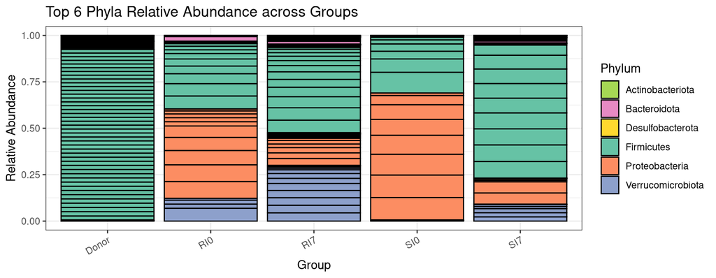

```r
source("code/assign_group.R")
# {r phylum-stacked-bar-final, fig.width=9, fig.height=4.5}

if (!"Group" %in% colnames(sample_data(scaled_physeq))) {
  sample_data(scaled_physeq)$Group <- sapply(
    sample_data(scaled_physeq)$SampleName,
    assign_group
  )
}

phylum_physeq <- scaled_physeq %>%
  tax_glom(taxrank = "Phylum")

phylum_df <- psmelt(phylum_physeq)

top6_phyla <- phylum_df %>%
  group_by(Phylum) %>%
  summarize(mean_abund = mean(Abundance)) %>%
  arrange(desc(mean_abund)) %>%
  slice_head(n = 6) %>%
  pull(Phylum)

phylum_colors <- c(
  "Firmicutes" = "#66C2A5",
  "Proteobacteria" = "#FC8D62",
  "Verrucomicrobiota" = "#8DA0CB",
  "Bacteroidota" = "#E78AC3",
  "Actinobacteriota" = "#A6D854",
  "Desulfobacterota" = "#FFD92F"
)

phylum_df %>%
  filter(Phylum %in% top6_phyla) %>%
  filter(Group %in% c("Donor", "RI0", "RI7", "SI0", "SI7")) %>%
  ggplot(aes(x = Group, y = Abundance, fill = Phylum)) +
  geom_bar(stat = "identity", position = "fill", color = "black") +
  scale_fill_manual(values = phylum_colors) +
  labs(
    title = "Top 6 Phyla Relative Abundance across Groups",
    x = "Group", y = "Relative Abundance"
  ) +
  theme_bw() +
  theme(
    axis.text.x = element_text(angle = 30, hjust = 1, vjust = 1),
    legend.position = "right",
    strip.text = element_text(face = "bold")
  )
```

## Faceted Bar plot

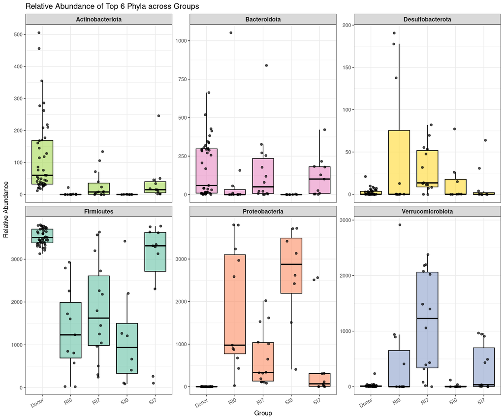

```r
# Plot Phylum relative abundance across Groups (Unified Style)

phylum_df %>%
  filter(Phylum %in% top6_phyla) %>%
  filter(Group %in% c("Donor", "RI0", "RI7", "SI0", "SI7")) %>%
  ggplot(aes(x = Group, y = Abundance, fill = Phylum)) +
  facet_wrap(~ Phylum, scales = "free_y", nrow = 2) +
  geom_boxplot(outlier.shape = NA, alpha = 0.6, color = "black") +
  geom_jitter(width = 0.2, size = 1.5, alpha = 0.7, color = "black") +
  scale_fill_manual(values = phylum_colors) +
  theme_bw() +
  labs(title = "Relative Abundance of Top 6 Phyla across Groups",
       x = "Group", y = "Relative Abundance") +
  theme(
    strip.text = element_text(size = 10, face = "bold"),
    axis.text.x = element_text(angle = 30, hjust = 1, vjust = 1),
    legend.position = "none"
  )
```

Interpretation #3: Based on the dotplot and boxplot analysis of the top 6 most abundant phyla, RBX2660 treatment appears to promote partial restoration of gut microbiota composition toward a donor-like structure.

Proteobacteria, a marker of dysbiosis, remained elevated in some RI7 samples, indicating incomplete recovery in recurrent cases.

Verrucomicrobiota expansion in RI7 samples may reflect microbiota instability or alternative ecological states post-treatment.

These patterns suggest that successful RBX2660 therapy restores Firmicutes and reduces Proteobacteria, but variability remains across patient responses, highlighting the need for individualized monitoring post-treatment.

## Firmicutes

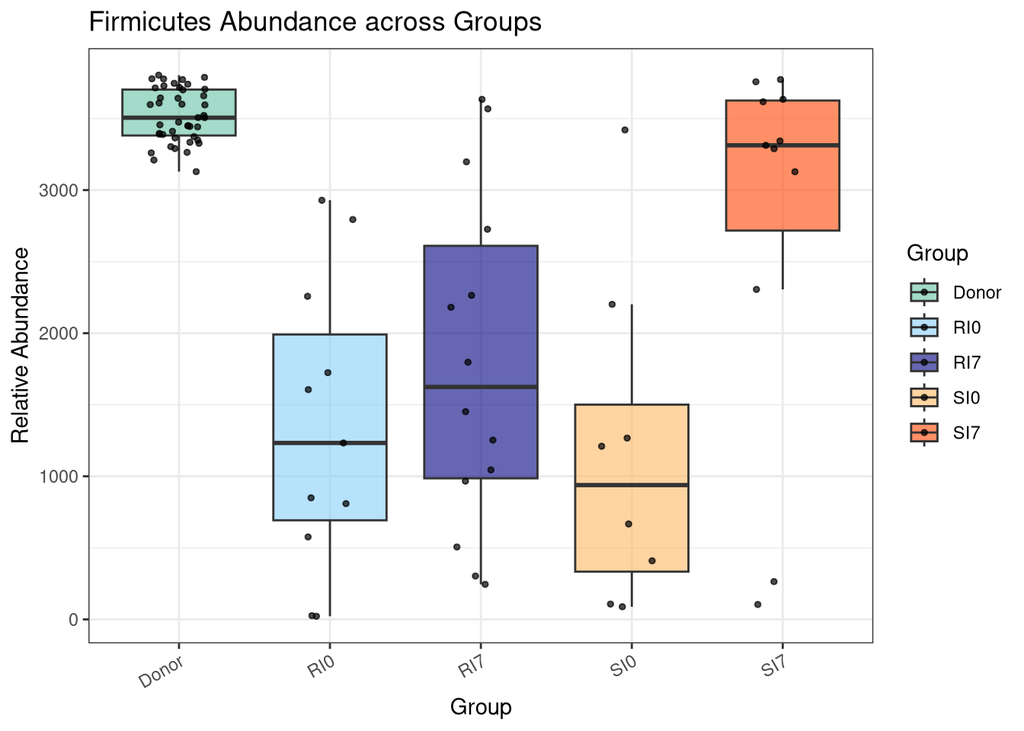

```r
group_colors <- c(
  "Donor" = "#66C2A5",
  "RI0" = "#87CEFA",
  "RI7" = "#000080",
  "SI0" = "#FDB863",
  "SI7" = "#FF4500"
)

phylum_df %>%
  filter(Phylum == "Firmicutes") %>%
  filter(Group %in% c("Donor", "RI0", "RI7", "SI0", "SI7")) %>%
  ggplot(aes(x = Group, y = Abundance, fill = Group)) +
  geom_boxplot(alpha = 0.6, outlier.shape = NA) +
  geom_jitter(width = 0.2, size = 1, alpha = 0.7) +
  scale_fill_manual(values = group_colors) +
  labs(title = "Firmicutes Abundance across Groups",
       x = "Group", y = "Relative Abundance") +
  theme_bw() +
  theme(axis.text.x = element_text(angle = 30, hjust = 1, vjust = 1))
```

## Proteobacteria

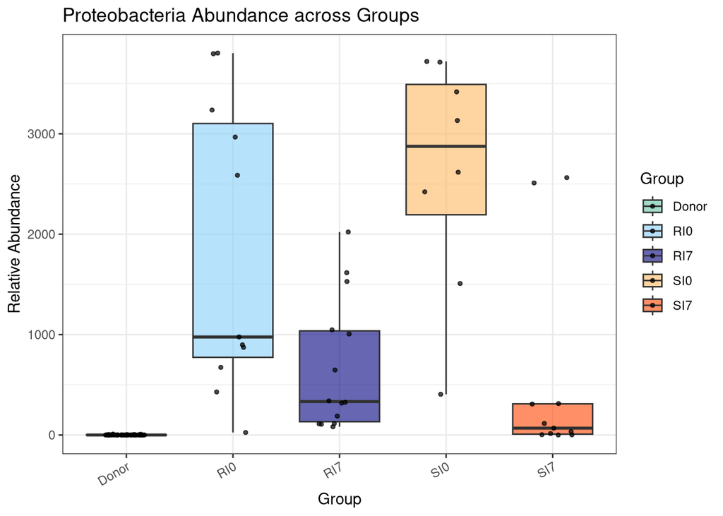

```r
phylum_df %>%
  filter(Phylum == "Proteobacteria") %>%
  filter(Group %in% c("Donor", "RI0", "RI7", "SI0", "SI7")) %>%
  ggplot(aes(x = Group, y = Abundance, fill = Group)) +
  geom_boxplot(alpha = 0.6, outlier.shape = NA) +
  geom_jitter(width = 0.2, size = 1, alpha = 0.7) +
  scale_fill_manual(values = group_colors) +
  labs(title = "Proteobacteria Abundance across Groups",
       x = "Group", y = "Relative Abundance") +
  theme_bw() +
  theme(axis.text.x = element_text(angle = 30, hjust = 1, vjust = 1))
```

## Verrucomicrobiota

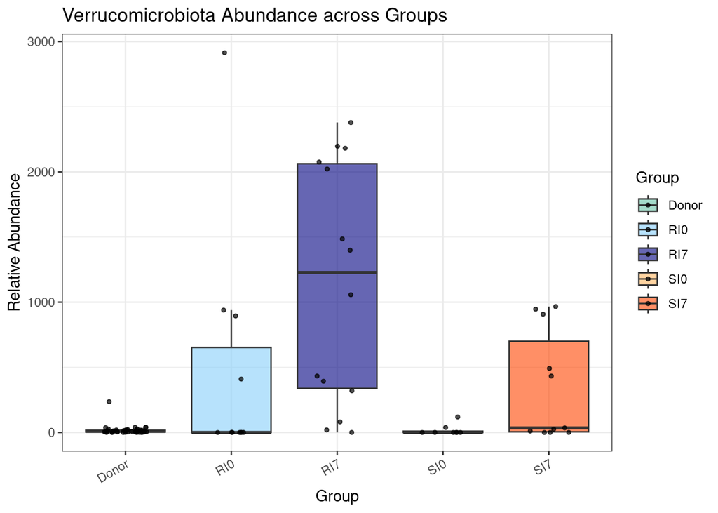

```r
phylum_df %>%
  filter(Phylum == "Verrucomicrobiota") %>%
  filter(Group %in% c("Donor", "RI0", "RI7", "SI0", "SI7")) %>%
  ggplot(aes(x = Group, y = Abundance, fill = Group)) +
  geom_boxplot(alpha = 0.6, outlier.shape = NA) +
  geom_jitter(width = 0.2, size = 1, alpha = 0.7) +
  scale_fill_manual(values = group_colors) +
  labs(title = "Verrucomicrobiota Abundance across Groups",
       x = "Group", y = "Relative Abundance") +
  theme_bw() +
  theme(axis.text.x = element_text(angle = 30, hjust = 1, vjust = 1))
```

## Desulfobacterota

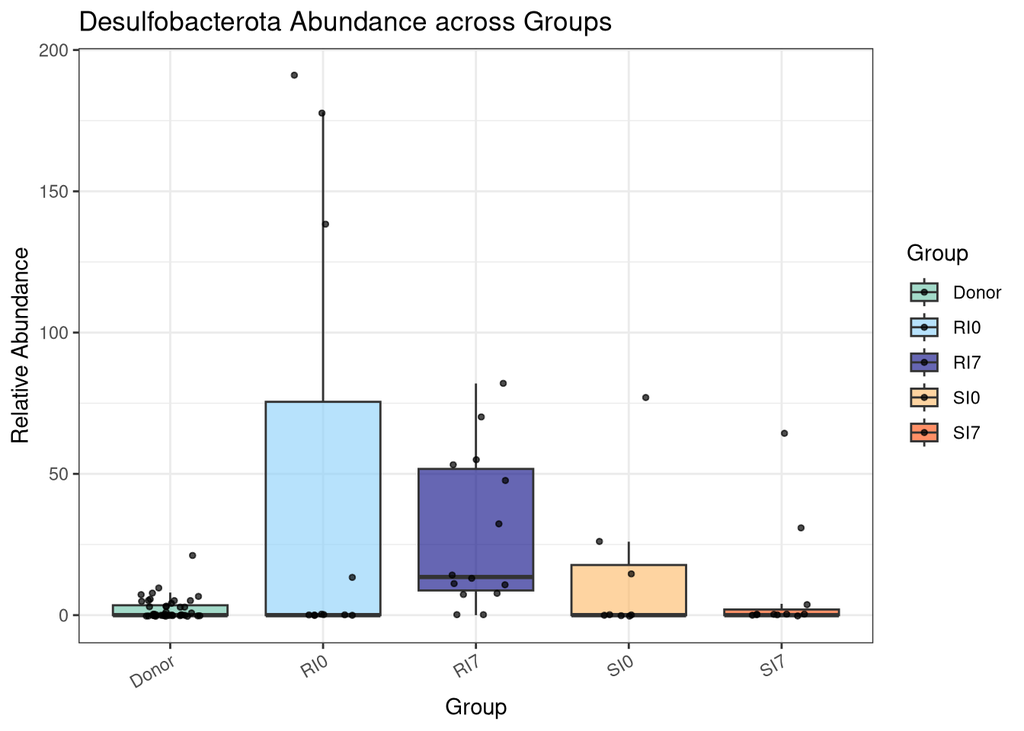

```r
phylum_df %>%
  filter(Phylum == "Desulfobacterota") %>%
  filter(Group %in% c("Donor", "RI0", "RI7", "SI0", "SI7")) %>%
  ggplot(aes(x = Group, y = Abundance, fill = Group)) +
  geom_boxplot(alpha = 0.6, outlier.shape = NA) +
  geom_jitter(width = 0.2, size = 1, alpha = 0.7) +
  scale_fill_manual(values = group_colors) +
  labs(title = "Desulfobacterota Abundance across Groups",
       x = "Group", y = "Relative Abundance") +
  theme_bw() +
  theme(axis.text.x = element_text(angle = 30, hjust = 1, vjust = 1))
```

In this study, we observed:

Firmicutes showed the highest relative abundance in Donor samples, but were markedly reduced in RI0 and SI0 (pre-treatment). After RBX2660 treatment, Firmicutes levels increased, with SI7 samples showing a more complete recovery toward Donor-like profiles compared to RI7.

Proteobacteria were substantially elevated in RI0 and SI0 (indicative of dysbiosis). Following treatment, SI7 samples exhibited a notable decrease in Proteobacteria abundance, while RI7 samples showed a smaller or more variable reduction, suggesting ongoing dysbiosis or delayed recovery in recurrent cases.

Actinobacteriota and Bacteroidota also shifted in expected directions toward a healthier microbiota, although their restoration was more gradual.

Notably, Verrucomicrobiota and Desulfobacterota showed substantial differences between RI0 and SI0 before treatment, suggesting baseline microbial composition heterogeneity across patients.

Together, these results suggest that while RBX2660 treatment broadly promotes microbiota restoration, the divergence between SI7 and RI7 likely reflects not only the influence of the donor microbiota, but also host factors (such as immune status or gut environment) and pre-existing microbiota differences.

Thus, successful microbiota-based therapy appears to depend on a combination of:

Baseline microbiota structure,

Donor microbial features,

Host physiological context (immune function, gut health).

This highlights the complexity and individuality of microbiota restoration following RBX2660 treatment and points to potential directions for deeper mechanistic investigations.

## B. Genus

```r
# Generate the Genus-level dataframe
genus_df <-
  scaled_physeq %>%
  tax_glom(taxrank = "Genus") %>%
  transform_sample_counts(function(x) x / sum(x)) %>%
  psmelt()
```

## Firmicutes Genera

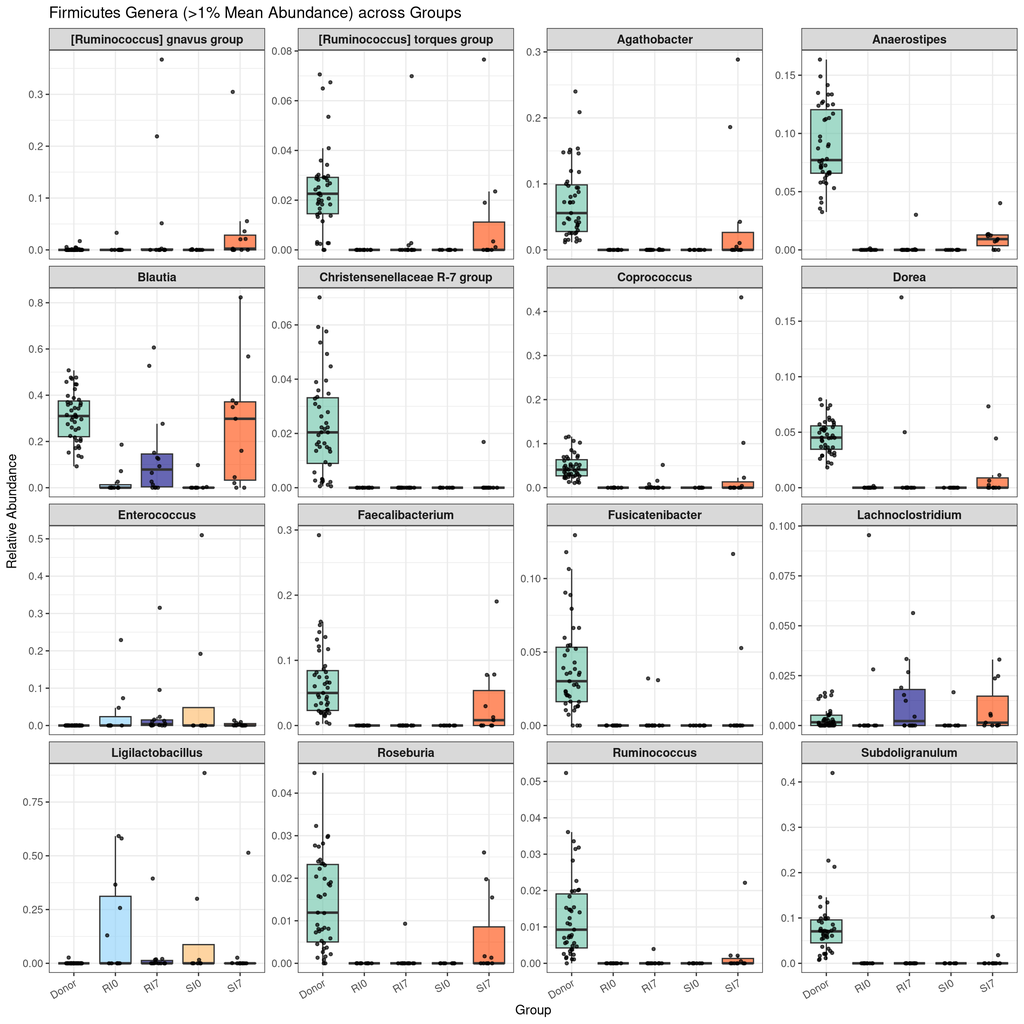

```r
selected_firmicutes_genus <-
  genus_df %>%
  filter(Phylum == "Firmicutes") %>%
  group_by(Genus) %>%
  summarise(mean_abund = mean(Abundance)) %>%
  filter(mean_abund > 0.01) %>%
  pull(Genus)

genus_df %>%
  filter(Phylum == "Firmicutes") %>%
  filter(Genus %in% selected_firmicutes_genus) %>%
  filter(Group %in% c("Donor", "RI0", "RI7", "SI0", "SI7")) %>%
  ggplot(aes(x = Group, y = Abundance, fill = Group)) +
  facet_wrap(~ Genus, scales = "free_y", nrow = 4) +  # <<<  nrow = 3 or 4
  geom_boxplot(alpha = 0.6, outlier.shape = NA) +
  geom_jitter(width = 0.2, size = 1, alpha = 0.7) +
  scale_fill_manual(values = group_colors) +
  labs(title = "Firmicutes Genera (>1% Mean Abundance) across Groups",
       x = "Group", y = "Relative Abundance") +
  theme_bw() +
  theme(
    axis.text.x = element_text(angle = 30, hjust = 1, vjust = 1),
    strip.text = element_text(face = "bold", size = 10),
    legend.position = "none"
  )
```

Brief Summary of Firmicutes Genera Changes:

In Donor samples: Classic beneficial genera such as Faecalibacterium, Blautia, Roseburia, and Anaerostipes were highly abundant.

After RI7 treatment: These beneficial genera did not recover effectively. Instead, there was a slight increase in potential pathogenic genera like [Ruminococcus] gnavus group and Lachnoclostridium.

After SI7 treatment: The key beneficial genera, including Faecalibacterium, Blautia, and Roseburia, were largely restored.

## Proteobacteria Genera

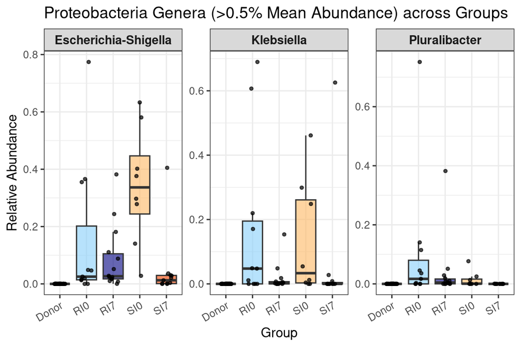

```r
selected_proteo_genus <-
  genus_df %>%
  filter(Phylum == "Proteobacteria") %>%
  group_by(Genus) %>%
  summarise(mean_abund = mean(Abundance)) %>%
  filter(mean_abund > 0.005) %>%
  pull(Genus)

genus_df %>%
  filter(Phylum == "Proteobacteria") %>%
  filter(Genus %in% selected_proteo_genus) %>%
  filter(Group %in% c("Donor", "RI0", "RI7", "SI0", "SI7")) %>%
  ggplot(aes(x = Group, y = Abundance, fill = Group)) +
  facet_wrap(~ Genus, scales = "free_y", nrow = 1) +
  geom_boxplot(alpha = 0.6, outlier.shape = NA) +
  geom_jitter(width = 0.2, size = 1, alpha = 0.7) +
  scale_fill_manual(values = group_colors) +
  labs(title = "Proteobacteria Genera (>0.5% Mean Abundance) across Groups",
       x = "Group", y = "Relative Abundance") +
  theme_bw() +
  theme(
    axis.text.x = element_text(angle = 30, hjust = 1, vjust = 1),
    strip.text = element_text(face = "bold", size = 10),
    legend.position = "none"
  )
```

Brief Summary of Proteobacteria Genera Changes:

In Donor samples, Escherichia-Shigella, Klebsiella, and Pluralibacter were nearly absent.

In RI patients, these potentially pathogenic genera were highly abundant at baseline (RI0) and showed only partial reductions after treatment (RI7).

In SI patients, these harmful genera were substantially reduced after treatment (SI7), approaching levels seen in healthy Donors.

This suggests that successful microbiota restoration (as seen in SI patients) effectively suppresses opportunistic pathogens in the gut.

## Verrucomicrobiota Genera

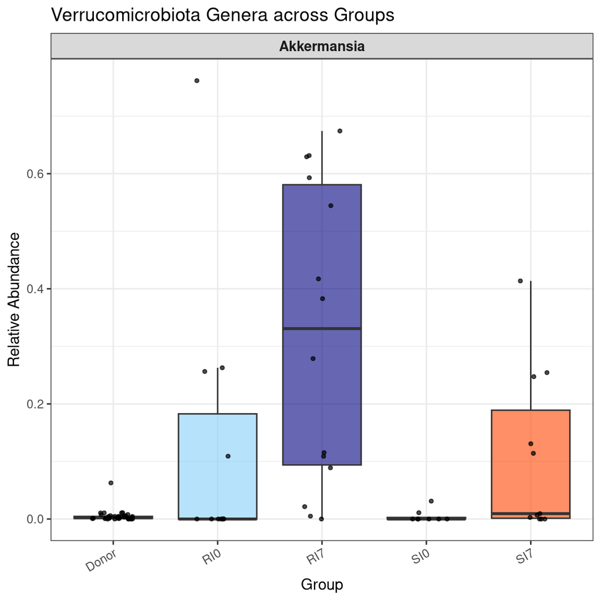

```r
selected_verruco_genus <-
  genus_df %>%
  filter(Phylum == "Verrucomicrobiota") %>%
  group_by(Genus) %>%
  summarise(mean_abund = mean(Abundance)) %>%
  pull(Genus)

genus_df %>%
  filter(Phylum == "Verrucomicrobiota") %>%
  filter(Genus %in% selected_verruco_genus) %>%
  filter(Group %in% c("Donor", "RI0", "RI7", "SI0", "SI7")) %>%
  ggplot(aes(x = Group, y = Abundance, fill = Group)) +
  facet_wrap(~ Genus, scales = "free_y", nrow = 2) +
  geom_boxplot(alpha = 0.6, outlier.shape = NA) +
  geom_jitter(width = 0.2, size = 1, alpha = 0.7) +
  scale_fill_manual(values = group_colors) +
  labs(title = "Verrucomicrobiota Genera across Groups",
       x = "Group", y = "Relative Abundance") +
  theme_bw() +
  theme(
    axis.text.x = element_text(angle = 30, hjust = 1, vjust = 1),
    strip.text = element_text(face = "bold", size = 10),
    legend.position = "none"
  )
```

## Desulfobacterota Genera

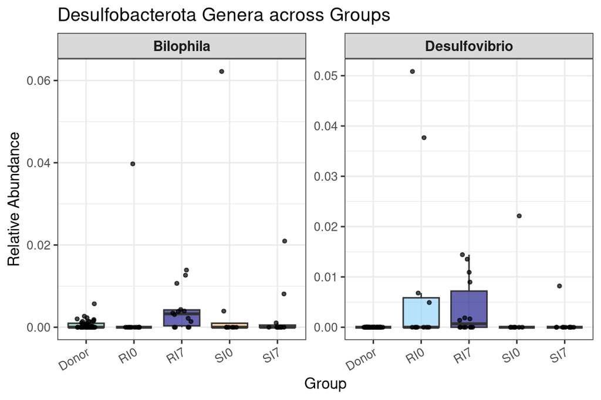

```r
selected_desulfo_genus <-
  genus_df %>%
  filter(Phylum == "Desulfobacterota") %>%
  group_by(Genus) %>%
  summarise(mean_abund = mean(Abundance)) %>%
  pull(Genus)

genus_df %>%
  filter(Phylum == "Desulfobacterota") %>%
  filter(Genus %in% selected_desulfo_genus) %>%
  filter(Group %in% c("Donor", "RI0", "RI7", "SI0", "SI7")) %>%
  ggplot(aes(x = Group, y = Abundance, fill = Group)) +
  facet_wrap(~ Genus, scales = "free_y", nrow = 1) +
  geom_boxplot(alpha = 0.6, outlier.shape = NA) +
  geom_jitter(width = 0.2, size = 1, alpha = 0.7) +
  scale_fill_manual(values = group_colors) +
  labs(title = "Desulfobacterota Genera across Groups",
       x = "Group", y = "Relative Abundance") +
  theme_bw() +
  theme(
    axis.text.x = element_text(angle = 30, hjust = 1, vjust = 1),
    strip.text = element_text(face = "bold", size = 10),
    legend.position = "none"
  )
```

Summary of Akkermansia, Bilophila, and Desulfovibrio Pre-treatment Differences Before treatment, significant microbial differences were already apparent between the RI0 and SI0 groups:

Akkermansia exhibited higher baseline abundance in the RI0 group compared to SI0 and Donor groups. Although Akkermansia is sometimes considered beneficial, excessive mucin degradation can impair gut barrier function, potentially predisposing patients to treatment failure.

After treatment:

In the RI7 group, these genera remained at abnormal levels or even increased further, suggesting a persistent dysbiotic signature.

At the genus level, our data revealed distinct microbial patterns associated with treatment success or failure.

Firmicutes genera: In healthy Donors, classic beneficial genera such as Faecalibacterium, Blautia, Roseburia, and Anaerostipes were highly abundant, contributing to a healthy gut environment. After SI7 treatment, these beneficial Firmicutes were largely restored. However, after RI7 treatment, these key genera remained depleted, and instead, an increase was observed in potential pathogenic genera like [Ruminococcus] gnavus group and Lachnoclostridium.

Proteobacteria genera: Pathogenic genera such as Escherichia-Shigella, Klebsiella, and Pluralibacter were nearly absent in Donor samples. In RI patients, these harmful taxa were highly enriched at baseline (RI0) and were only partially reduced after treatment (RI7). In contrast, SI7 samples showed effective suppression of these genera, reaching levels similar to Donors.

Conclusion: The persistence of pathogenic genera and the failure to restore key beneficial taxa likely contributed to microbiota engraftment failure and disease recurrence in the RI group. In contrast, successful recovery of a beneficial genus profile (especially within Firmicutes) was observed in the SI group, closely resembling Donor microbial communities.

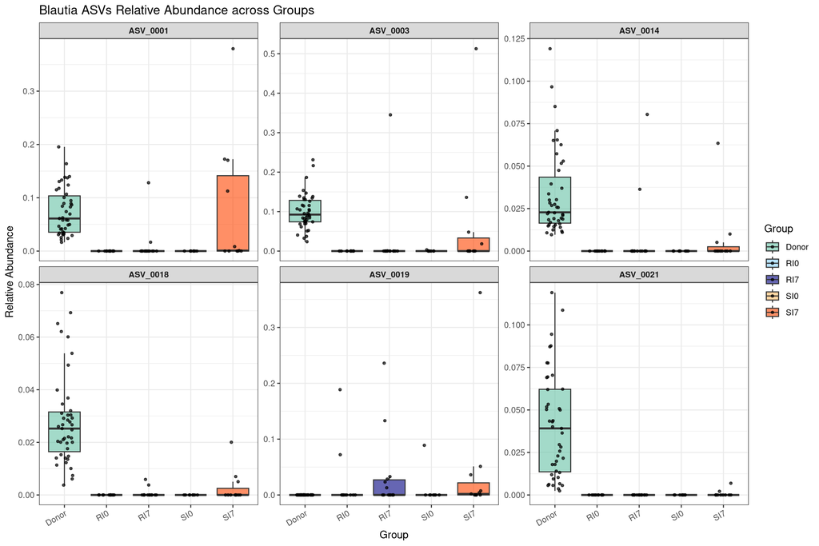

```r
ASV_df <- scaled_physeq %>%
  prune_taxa(taxa_sums(.) >= 100, .) %>%
  transform_sample_counts(function(x) x / sum(x)) %>%
  psmelt() %>%
  rename(SampleID = sample_Sample)


metadata_fixed <- read.csv("data/metadata.csv") %>%
  mutate(Group = sapply(SampleName, assign_group)) %>%
  select(SampleName, Group)


ASV_df <- ASV_df %>%
  left_join(metadata_fixed, by = "SampleName")


ASV_df <- ASV_df %>%
  rename(Group = Group.x) %>%
  select(-Group.y)

top_blautia_asvs <- ASV_df %>%
  filter(Genus == "Blautia") %>%
  group_by(OTU) %>%
  summarise(mean_abund = mean(Abundance)) %>%
  filter(mean_abund > 0.005, !OTU %in% c("ASV_0024", "ASV_0034")) %>%
  pull(OTU)

library(ggplot2)

blautia_plot <- ASV_df %>%
  filter(OTU %in% top_blautia_asvs,
         Group %in% c("Donor", "RI0", "RI7", "SI0", "SI7")) %>%
  ggplot(aes(x = Group, y = Abundance, fill = Group)) +
  facet_wrap(~ OTU, scales = "free_y", nrow = 2) +
  geom_boxplot(alpha = 0.6, outlier.shape = NA) +
  geom_jitter(width = 0.2, size = 1, alpha = 0.7) +
  scale_fill_manual(values = group_colors) +
  labs(title = "Blautia ASVs Relative Abundance across Groups",
       x = "Group", y = "Relative Abundance") +
  theme_bw() +
  theme(strip.text = element_text(face = "bold"),
        axis.text.x = element_text(angle = 30, hjust = 1, vjust = 1))

blautia_plot
```

```r
ASV_df <- scaled_physeq %>%
  prune_taxa(taxa_sums(.) >= 100, .) %>%
  transform_sample_counts(function(x) x / sum(x)) %>%
  psmelt() %>%
  rename(SampleID = sample_Sample)

metadata_fixed <- read.csv("data/metadata.csv") %>%
  mutate(Group = sapply(SampleName, assign_group)) %>%
  select(SampleName, Group)

ASV_df <- ASV_df %>%
  left_join(metadata_fixed, by = "SampleName")

ASV_df <- ASV_df %>%
  rename(Group = Group.x) %>%
  select(-Group.y)

top_desulfo_asvs <- ASV_df %>%
  filter(Genus == "Desulfovibrio") %>%
  group_by(OTU) %>%
  summarise(mean_abund = mean(Abundance)) %>%
  pull(OTU)

desulfo_plot <- ASV_df %>%
  filter(OTU %in% top_desulfo_asvs,
         Group %in% c("Donor", "RI0", "RI7", "SI0", "SI7")) %>%
  ggplot(aes(x = Group, y = Abundance, fill = Group)) +
  facet_wrap(~ OTU, scales = "free_y", nrow = 1) +
  geom_boxplot(alpha = 0.6, outlier.shape = NA) +
  geom_jitter(width = 0.2, size = 1, alpha = 0.7) +
  scale_fill_manual(values = group_colors) +
  labs(title = "Desulfovibrio ASVs Relative Abundance across Groups",
       x = "Group", y = "Relative Abundance") +
  theme_bw() +
  theme(strip.text = element_text(face = "bold"),
        axis.text.x = element_text(angle = 30, hjust = 1, vjust = 1))

## desulfo_plot
```

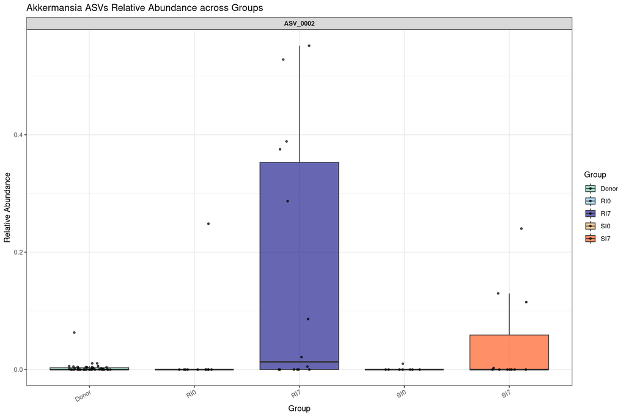

```r
# --- Akkermansia ASV Analysis ---
top_akk_asvs <- ASV_df %>%
  filter(Genus == "Akkermansia") %>%
  group_by(OTU) %>%
  summarise(mean_abund = mean(Abundance)) %>%
  filter(mean_abund > 0.03) %>%
  pull(OTU)

akk_plot <- ASV_df %>%
  filter(OTU %in% top_akk_asvs,
         Group %in% c("Donor", "RI0", "RI7", "SI0", "SI7")) %>%
  ggplot(aes(x = Group, y = Abundance, fill = Group)) +
  facet_wrap(~ OTU, scales = "free_y", nrow = 2) +
  geom_boxplot(alpha = 0.6, outlier.shape = NA) +
  geom_jitter(width = 0.2, size = 1, alpha = 0.7) +
  scale_fill_manual(values = group_colors) +
  labs(title = "Akkermansia ASVs Relative Abundance across Groups",
       x = "Group", y = "Relative Abundance") +
  theme_bw() +
  theme(strip.text = element_text(face = "bold"),
        axis.text.x = element_text(angle = 30, hjust = 1, vjust = 1))

akk_plot
```

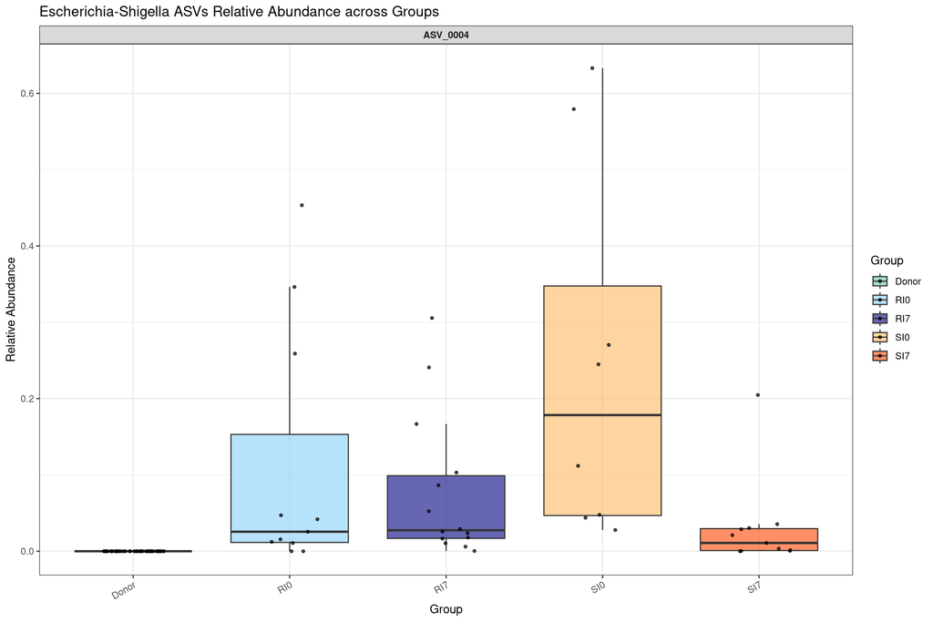

```r
# --- Escherichia-Shigella ASV Analysis ---
top_escher_asvs <- ASV_df %>%
  filter(Genus == "Escherichia-Shigella") %>%
  group_by(OTU) %>%
  summarise(mean_abund = mean(Abundance)) %>%
  filter(mean_abund > 0.005) %>%
  pull(OTU)

escher_plot <- ASV_df %>%
  filter(OTU %in% top_escher_asvs,
         Group %in% c("Donor", "RI0", "RI7", "SI0", "SI7")) %>%
  ggplot(aes(x = Group, y = Abundance, fill = Group)) +
  facet_wrap(~ OTU, scales = "free_y", nrow = 2) +
  geom_boxplot(alpha = 0.6, outlier.shape = NA) +
  geom_jitter(width = 0.2, size = 1, alpha = 0.7) +
  scale_fill_manual(values = group_colors) +
  labs(title = "Escherichia-Shigella ASVs Relative Abundance across Groups",
       x = "Group", y = "Relative Abundance") +
  theme_bw() +
  theme(strip.text = element_text(face = "bold"),
        axis.text.x = element_text(angle = 30, hjust = 1, vjust = 1))

escher_plot
```

Our ASV-level plots successfully captured several of the most abundant ASVs in the entire dataset. Specifically, ASV_0001, ASV_0002, ASV_0003, and ASV_0004 were all included in the focused visualizations for the genera Blautia, Akkermansia, and Escherichia-Shigella

The ASV-level plots provide high-resolution insights into microbial dynamics following FMT, revealing patterns that are consistent with observed treatment outcomes. Notably, ASVs within Blautia, Akkermansia, and Escherichia-Shigella displayed trends that closely mirror either successful microbiota engraftment or persistent dysbiosis.

Interestingly, the ASV-level analysis of Akkermansia revealed a single ASV (ASV_0002) that spiked dramatically in the RI7 group, despite being nearly absent in donors, SI0 and RI0 samples. This points to a possible overgrowth or unstable colonization event, potentially reflecting mucosal disruption or host incompatibility. In contrast, SI recipients maintained relatively low levels of this ASV, which may indicate a more stable and less perturbed recovery trajectory.

Altogether, these ASV-specific trends suggest that different outcomes in microbial restoration are driven not only by genus-level shifts, but also by the behavior of distinct ASVs. The SI group exhibited signs of successful donor engraftment, controlled recovery, and reduced opportunistic expansion, while the RI group appeared to retain dysbiotic features or experience unstable shifts. These findings emphasize the importance of ASV-level analysis in uncovering subtle, yet biologically meaningful, patterns following microbiome interventions.

Our ASV-level findings both confirm previously reported associations and reveal potentially novel dynamics following FMT. Specifically, ASVs corresponding to Blautia (ASV_0001 and ASV_0003) and Escherichia-Shigella (ASV_0004) mirror trends described in Langdon et al. (2021), where successful FMT recipients (SI group) showed clear reappearance of Blautia ASVs and a consistent reduction in Escherichia-Shigella abundance. These patterns reinforce the idea that certain beneficial or pathogenic taxa at the ASV level can serve as microbial indicators of treatment success or persistent dysbiosis.

In contrast, the behavior of Akkermansia (ASV_0002) in our analysis offers an additional perspective not fully explored in the original study. While Akkermansia is generally associated with gut health, we observed a marked spike of ASV_0002 specifically in RI patients at day 7, despite its near absence in donors and SI samples. This suggests a potential link to unstable recovery or mucosal disruption in patients who failed initial therapy, pointing to a role for Akkermansia dynamics as a marker of microbial instability.

Overall, this analysis underscores the value of ASV-level resolution, which enables us to detect fine-scale differences in microbial trajectories that are not always visible at genus level. It highlights that post-FMT microbiome recovery is not just driven by broad taxonomic shifts but by specific ASV dynamics—some of which may serve as early predictors of therapeutic outcome.